# house_prediction_with_corrections_v2

```python
# This Python 3 environment comes with many helpful analytics libraries installed
# It is defined by the kaggle/python Docker image: https://github.com/kaggle/docker-python
# For example, here's several helpful packages to load

import numpy as np # linear algebra
import pandas as pd # data processing, CSV file I/O (e.g. pd.read_csv)

# Input data files are available in the read-only "../input/" directory
# For example, running this (by clicking run or pressing Shift+Enter) will list all files under the input directory

import os
for dirname, _, filenames in os.walk('/kaggle/input'):
    for filename in filenames:
        print(os.path.join(dirname, filename))

# You can write up to 20GB to the current directory (/kaggle/working/) that gets preserved as output when you create a version using "Save & Run All"
# You can also write temporary files to /kaggle/temp/, but they won't be saved outside of the current session
```

```python
df = pd.read_csv('housing.csv')
df.head()
```

|  | longitude | latitude | housing_median_age | total_rooms | total_bedrooms | population | households | median_income | median_house_value | ocean_proximity |
| --- | --- | --- | --- | --- | --- | --- | --- | --- | --- | --- |
| 0 | -122.23 | 37.88 | 41.0 | 880.0 | 129.0 | 322.0 | 126.0 | 8.3252 | 452600.0 | NEAR BAY |
| 1 | -122.22 | 37.86 | 21.0 | 7099.0 | 1106.0 | 2401.0 | 1138.0 | 8.3014 | 358500.0 | NEAR BAY |
| 2 | -122.24 | 37.85 | 52.0 | 1467.0 | 190.0 | 496.0 | 177.0 | 7.2574 | 352100.0 | NEAR BAY |
| 3 | -122.25 | 37.85 | 52.0 | 1274.0 | 235.0 | 558.0 | 219.0 | 5.6431 | 341300.0 | NEAR BAY |
| 4 | -122.25 | 37.85 | 52.0 | 1627.0 | 280.0 | 565.0 | 259.0 | 3.8462 | 342200.0 | NEAR BAY |

```python
df.info()
```

```
<class 'pandas.core.frame.DataFrame'>
RangeIndex: 20640 entries, 0 to 20639
Data columns (total 10 columns):
 #   Column              Non-Null Count  Dtype
---  ------              --------------  -----
 0   longitude           20640 non-null  float64
 1   latitude            20640 non-null  float64
 2   housing_median_age  20640 non-null  float64
 3   total_rooms         20640 non-null  float64
 4   total_bedrooms      20433 non-null  float64
 5   population          20640 non-null  float64
 6   households          20640 non-null  float64
 7   median_income       20640 non-null  float64
 8   median_house_value  20640 non-null  float64
 9   ocean_proximity     20640 non-null  object
dtypes: float64(9), object(1)
memory usage: 1.6+ MB
```

```python
# Ocen proximity has object dtype
df['ocean_proximity'].value_counts()
```

| ocean_proximity | count |
| --- | --- |
| <1H OCEAN | 9136 |
| INLAND | 6551 |
| NEAR OCEAN | 2658 |
| NEAR BAY | 2290 |
| ISLAND | 5 |

**dtype:** int64

```python
df.describe()
# Gives the summary for numerical attributes.
```

|  | longitude | latitude | housing_median_age | total_rooms | total_bedrooms | population | households | median_income | median_house_value |
| --- | --- | --- | --- | --- | --- | --- | --- | --- | --- |
| count | 20640.000000 | 20640.000000 | 20640.000000 | 20640.000000 | 20433.000000 | 20640.000000 | 20640.000000 | 20640.000000 | 20640.000000 |
| mean | -119.569704 | 35.631861 | 28.639486 | 2635.763081 | 537.870553 | 1425.476744 | 499.539680 | 3.870671 | 206855.816909 |
| std | 2.003532 | 2.135952 | 12.585558 | 2181.615252 | 421.385070 | 1132.462122 | 382.329753 | 1.899822 | 115395.615874 |
| min | -124.350000 | 32.540000 | 1.000000 | 2.000000 | 1.000000 | 3.000000 | 1.000000 | 0.499900 | 14999.000000 |
| 25% | -121.800000 | 33.930000 | 18.000000 | 1447.750000 | 296.000000 | 787.000000 | 280.000000 | 2.563400 | 119600.000000 |
| 50% | -118.490000 | 34.260000 | 29.000000 | 2127.000000 | 435.000000 | 1166.000000 | 409.000000 | 3.534800 | 179700.000000 |
| 75% | -118.010000 | 37.710000 | 37.000000 | 3148.000000 | 647.000000 | 1725.000000 | 605.000000 | 4.743250 | 264725.000000 |
| max | -114.310000 | 41.950000 | 52.000000 | 39320.000000 | 6445.000000 | 35682.000000 | 6082.000000 | 15.000100 | 500001.000000 |

## The median income attribute does not look like it is expressed in US dollars (USD). After checking with the team that collected the data, you are told that the data has been scaled and capped at 15 (actually 15.0001) for higher median incomesmedian incomes and at 0.5 (actually 0.4999) for lower median incomes. Working with preprocessed attributes is common in Machine Learning, and it is not necessarilya problem, but you should try to understand how the data was computed.

## Also median age and the median house value were also capped.

The capping part means:

If a district's median income was very high (say $200,000+), it was capped and recorded as 15.0001 — no value goes above this. If a district's median income was very low, it was capped and recorded as 0.4999 — no value goes below this.

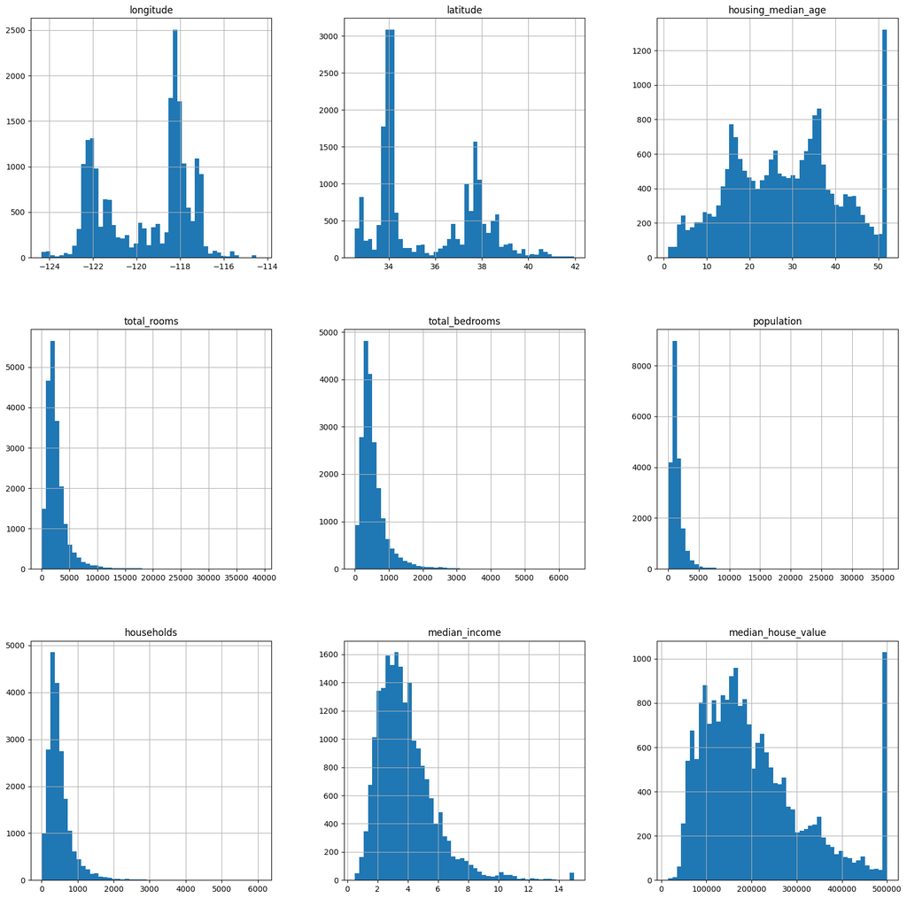

```python
%matplotlib inline
import matplotlib.pyplot as plt
df.hist(bins = 50, figsize = (20,20))
plt.show()
```

## Create test set.

```python
from sklearn.model_selection import train_test_split
train_set, test_set = train_test_split(df, test_size = 0.2, random_state =42)
```

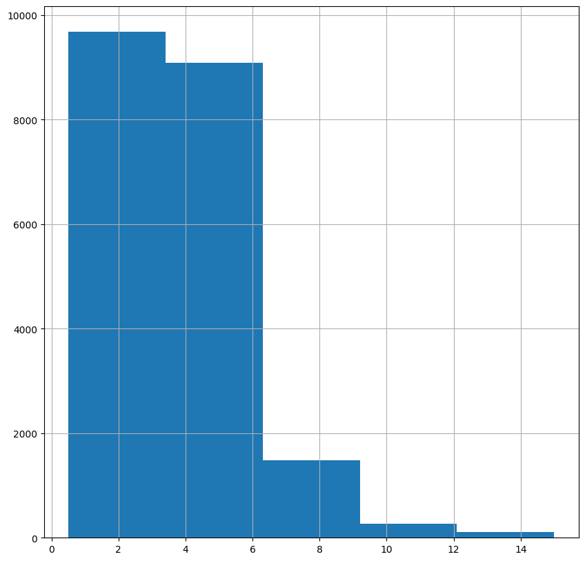

```python
# plt.hist(df['median_income'],bins = 50, figsize = (10,10))
# plt.show()
df['median_income'].hist(figsize = (10,10), bins = 5)
```

```python
df['income_cat'] = np.ceil(df['median_income']/1.5)
df['income_cat'].where(df['income_cat']< 5,5.0)
```

|  | income_cat |
| --- | --- |
| 0 | 5.0 |
| 1 | 5.0 |
| 2 | 5.0 |
| 3 | 4.0 |
| 4 | 3.0 |
| ... | ... |
| 20635 | 2.0 |
| 20636 | 2.0 |
| 20637 | 2.0 |
| 20638 | 2.0 |
| 20639 | 2.0 |

20640 rows × 1 columns

**dtype:** float64

```python
# Fix: cap the income categories properly before checking the distribution.
df['income_cat'] = np.ceil(df['median_income'] / 1.5)
df['income_cat'] = df['income_cat'].clip(upper=5)

df['income_cat'].value_counts().sort_index()
```

| income_cat | count |
| --- | --- |
| 1.0 | 822 |
| 2.0 | 6581 |
| 3.0 | 7236 |
| 4.0 | 3639 |
| 5.0 | 2362 |

**dtype:** int64

```python
from sklearn.model_selection import StratifiedShuffleSplit
split = StratifiedShuffleSplit(n_splits = 1, test_size =0.2, random_state =42)
for train_index, test_index in split.split(df, df['income_cat']):
    strat_train_set = df.loc[train_index]
    start_test_set = df.loc[test_index]
```

```python
# Fix: the variable should be named `test_set`, not `start_test_set`.
# Also, `income_cat` is only for stratified sampling, so remove it after the split.
from sklearn.model_selection import StratifiedShuffleSplit

split = StratifiedShuffleSplit(n_splits=1, test_size=0.2, random_state=42)
for train_index, test_index in split.split(df, df['income_cat']):
    strat_train_set = df.loc[train_index]
    test_set = df.loc[test_index]

for set_ in (strat_train_set, test_set):
    set_.drop('income_cat', axis=1, inplace=True)
```

**Stratified Sampling is a sampling technique where you divide your data into subgroups (strata) and sample from each group proportionally.

```python
df['income_cat'].value_counts() / len(df)
```

| income_cat | count |
| --- | --- |
| 3.0 | 0.350581 |
| 2.0 | 0.318847 |
| 4.0 | 0.176308 |
| 5.0 | 0.114438 |
| 1.0 | 0.039826 |

**dtype:** float64

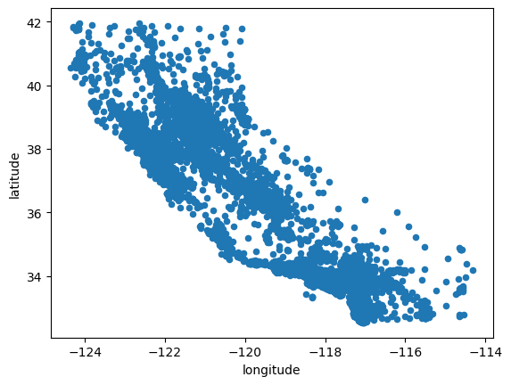

```python
df.plot(kind = 'scatter', x = 'longitude', y = 'latitude')
```

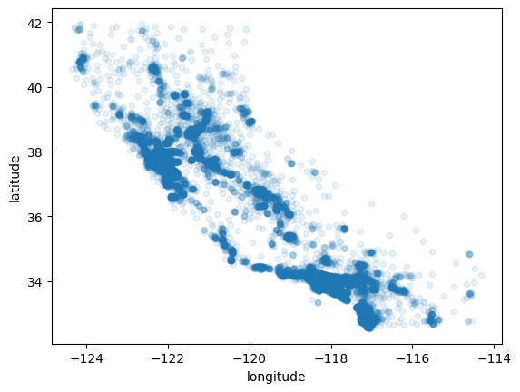

```python
df.plot(kind = 'scatter', x = 'longitude', y = 'latitude', alpha = 0.1)
```

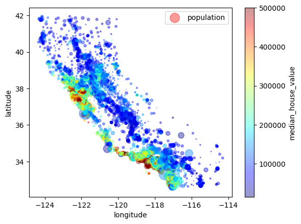

```python
df.plot(kind = 'scatter', x = 'longitude', y = 'latitude', alpha = 0.4,
       s = df['population']/100, label ='population',
       c = 'median_house_value', cmap = plt.get_cmap('jet'), colorbar = True)
plt.legend()
```

```python
df.info()
```

```
<class 'pandas.core.frame.DataFrame'>
RangeIndex: 20640 entries, 0 to 20639
Data columns (total 11 columns):
 #   Column              Non-Null Count  Dtype
---  ------              --------------  -----
 0   longitude           20640 non-null  float64
 1   latitude            20640 non-null  float64
 2   housing_median_age  20640 non-null  float64
 3   total_rooms         20640 non-null  float64
 4   total_bedrooms      20433 non-null  float64
 5   population          20640 non-null  float64
 6   households          20640 non-null  float64
 7   median_income       20640 non-null  float64
 8   median_house_value  20640 non-null  float64
 9   ocean_proximity     20640 non-null  object
 10  income_cat          20640 non-null  float64
dtypes: float64(10), object(1)
memory usage: 1.7+ MB
```

```python
corr_matrix = df.drop('ocean_proximity', axis = 1).corr()
corr_matrix['median_house_value'].sort_values(ascending = False)
```

|  | median_house_value |
| --- | --- |
| median_house_value | 1.000000 |
| median_income | 0.688075 |
| income_cat | 0.643892 |
| total_rooms | 0.134153 |
| housing_median_age | 0.105623 |
| households | 0.065843 |
| total_bedrooms | 0.049686 |
| population | -0.024650 |
| longitude | -0.045967 |
| latitude | -0.144160 |

**dtype:** float64

```
array([[<Axes: xlabel='median_house_value', ylabel='median_house_value'>,
        <Axes: xlabel='median_income', ylabel='median_house_value'>,
        <Axes: xlabel='total_rooms', ylabel='median_house_value'>,
        <Axes: xlabel='housing_median_age', ylabel='median_house_value'>],
       [<Axes: xlabel='median_house_value', ylabel='median_income'>,
        <Axes: xlabel='median_income', ylabel='median_income'>,
        <Axes: xlabel='total_rooms', ylabel='median_income'>,
        <Axes: xlabel='housing_median_age', ylabel='median_income'>],
       [<Axes: xlabel='median_house_value', ylabel='total_rooms'>,
        <Axes: xlabel='median_income', ylabel='total_rooms'>,
        <Axes: xlabel='total_rooms', ylabel='total_rooms'>,
        <Axes: xlabel='housing_median_age', ylabel='total_rooms'>],
       [<Axes: xlabel='median_house_value', ylabel='housing_median_age'>,
        <Axes: xlabel='median_income', ylabel='housing_median_age'>,
        <Axes: xlabel='total_rooms', ylabel='housing_median_age'>,
        <Axes: xlabel='housing_median_age', ylabel='housing_median_age'>]],
      dtype=object)
```

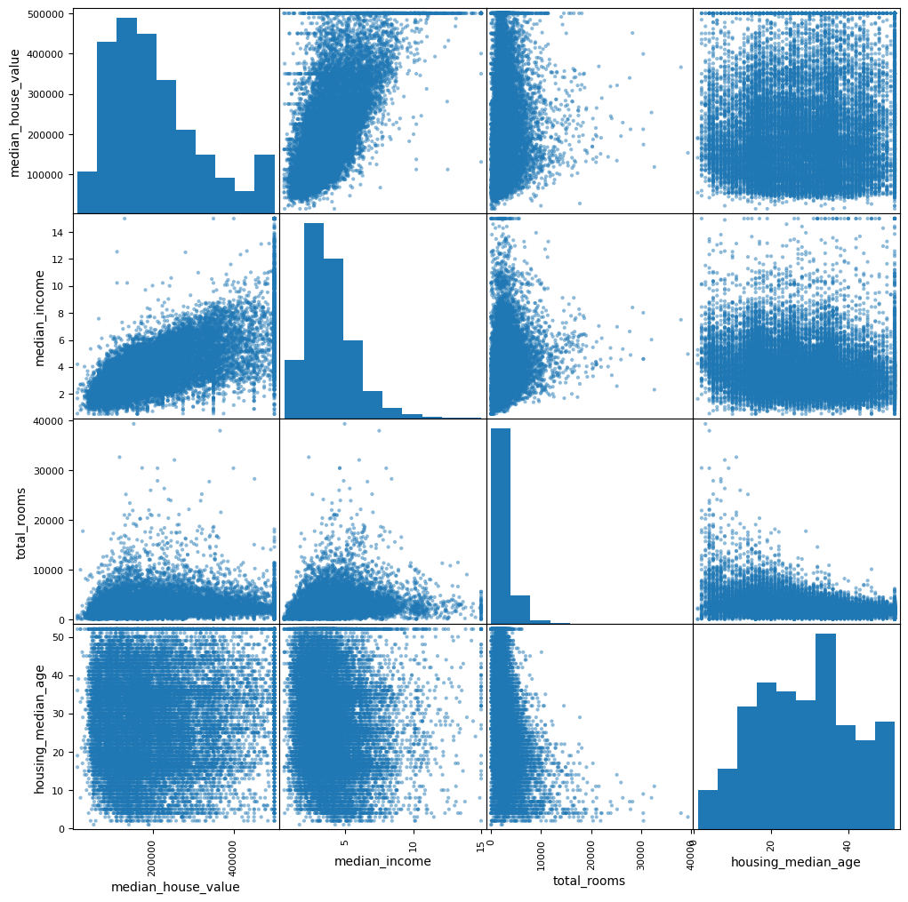

```python
from pandas.plotting import scatter_matrix
attributes = ['median_house_value', 'median_income', 'total_rooms','housing_median_age']
scatter_matrix(df[attributes], figsize=(12,12))
```

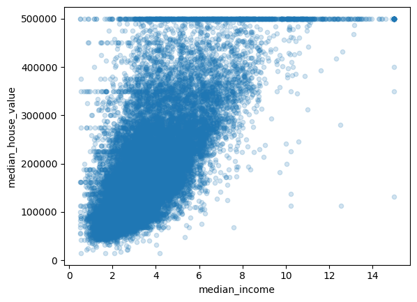

```python
# we need median_income and median_house_value
df.plot(kind = 'scatter', x = 'median_income', y = 'median_house_value', alpha = 0.2)
```

**One last thing you may want to do before actually preparing the data for Machine Learning algorithms is to try out various attribute combinations. For example, the total number of rooms in a district is not very useful if you don’t know how many households there are. What you really want is the number of rooms per household. Similarly, the total number of bedrooms by itself is not very useful: you probably want to compare it to the number of rooms. And the population per household also seems like an interesting attribute combination to look at. Let’s create these new attributes:**

```python
df['rooms_per_household'] = df['total_rooms']/ df['households']
df['bedrooms_per_room'] = df['total_bedrooms']/ df['total_rooms']
df['population_per_household'] = df['population']/df['households']
```

```python
df.info()
```

```
<class 'pandas.core.frame.DataFrame'>
RangeIndex: 20640 entries, 0 to 20639
Data columns (total 14 columns):
 #   Column                    Non-Null Count  Dtype
---  ------                    --------------  -----
 0   longitude                 20640 non-null  float64
 1   latitude                  20640 non-null  float64
 2   housing_median_age        20640 non-null  float64
 3   total_rooms               20640 non-null  float64
 4   total_bedrooms            20433 non-null  float64
 5   population                20640 non-null  float64
 6   households                20640 non-null  float64
 7   median_income             20640 non-null  float64
 8   median_house_value        20640 non-null  float64
 9   ocean_proximity           20640 non-null  object
 10  income_cat                20640 non-null  float64
 11  rooms_per_household       20640 non-null  float64
 12  bedrooms_per_room         20433 non-null  float64
 13  population_per_household  20640 non-null  float64
dtypes: float64(13), object(1)
memory usage: 2.2+ MB
```

```python
corr_matrix = df.drop(['ocean_proximity'],axis = 1).corr()
corr_matrix['median_house_value'].sort_values(ascending = False)
```

|  | median_house_value |
| --- | --- |
| median_house_value | 1.000000 |
| median_income | 0.688075 |
| income_cat | 0.643892 |
| rooms_per_household | 0.151948 |
| total_rooms | 0.134153 |
| housing_median_age | 0.105623 |
| households | 0.065843 |
| total_bedrooms | 0.049686 |
| population_per_household | -0.023737 |
| population | -0.024650 |
| longitude | -0.045967 |
| latitude | -0.144160 |
| bedrooms_per_room | -0.255880 |

**dtype:** float64

```python
# At the start of your notebook
df = pd.read_csv('housing.csv')

# Then do all your steps in order
housing_label = df['median_house_value'].copy()
df = df.drop('median_house_value', axis=1)
```

```python
df = strat_train_set.copy()  # this is what the book uses

# Add your custom attributes again
df['rooms_per_household'] = df['total_rooms'] / df['households']
df['bedrooms_per_room'] = df['total_bedrooms'] / df['total_rooms']
df['population_per_household'] = df['population'] / df['households']

# Now separate correctly
housing_label = df['median_house_value'].copy()
df = df.drop('median_house_value', axis=1)
```

## Handling text and Categorical Attributes

```python
from sklearn.preprocessing import LabelEncoder
encoder = LabelEncoder()
housing_cat = df['ocean_proximity']
housing_cat_encoded = encoder.fit_transform(housing_cat)
housing_cat_encoded
```

```
array([1, 4, 1, ..., 0, 0, 1])
```

```python
print(encoder.classes_)
```

```
['<1H OCEAN' 'INLAND' 'ISLAND' 'NEAR BAY' 'NEAR OCEAN']
```

```python
from sklearn.preprocessing import OneHotEncoder
encoder = OneHotEncoder()
housing_cat_1hot = encoder.fit_transform(housing_cat_encoded.reshape(-1,1))
housing_cat_1hot
```

```
<Compressed Sparse Row sparse matrix of dtype 'float64'
	with 16512 stored elements and shape (16512, 5)>
```

```python
housing_cat_1hot.toarray()
```

```
array([[0., 1., 0., 0., 0.],
       [0., 0., 0., 0., 1.],
       [0., 1., 0., 0., 0.],
       ...,
       [1., 0., 0., 0., 0.],
       [1., 0., 0., 0., 0.],
       [0., 1., 0., 0., 0.]])
```

**We can apply both transformations (from text categories to integer categories, then from integer categories to one-hot vectors) in one shot using the LabelBinarizer class:**

```python
from sklearn.preprocessing import LabelBinarizer
encoder = LabelBinarizer()
housing_cat_1hot = encoder.fit_transform(housing_cat)
housing_cat_1hot
```

```
array([[0, 1, 0, 0, 0],
       [0, 0, 0, 0, 1],
       [0, 1, 0, 0, 0],
       ...,
       [1, 0, 0, 0, 0],
       [1, 0, 0, 0, 0],
       [0, 1, 0, 0, 0]])
```

```python
from sklearn.base import BaseEstimator, TransformerMixin

rooms_ix, bedrooms_ix, population_ix, household_ix = 3, 4, 5, 6

class CombinedAttributesAdder(BaseEstimator, TransformerMixin):
    def __init__(self, add_bedrooms_per_room=True):
        self.add_bedrooms_per_room = add_bedrooms_per_room

    def fit(self, X, y=None):
        return self

    def transform(self, X, y=None):
        rooms_per_household = X[:, rooms_ix] / X[:, household_ix]
        population_per_household = X[:, population_ix] / X[:, household_ix]
        if self.add_bedrooms_per_room:
            bedrooms_per_room = X[:, bedrooms_ix] / X[:, rooms_ix]
            return np.c_[X, rooms_per_household, population_per_household, bedrooms_per_room]
        else:
            return np.c_[X, rooms_per_household, population_per_household]

# Use it
attr_adder = CombinedAttributesAdder(add_bedrooms_per_room=False)
df_extra_attribs = attr_adder.transform(df.values)
```

## Feature scaling

**There are 2 types of Scaling:

1. Min-max scaling
2. standardization**

```python
from sklearn.pipeline import Pipeline
from sklearn.preprocessing import StandardScaler
from sklearn.impute import SimpleImputer
```

```python
num_pipelin = Pipeline([
    ('imputer', SimpleImputer(strategy = 'median')),
    ('attribs_adder', CombinedAttributesAdder()),
    ('Std_scaler', StandardScaler())

])
```

```python
housing_num = df.drop("ocean_proximity", axis=1)
```

```python
housing_num_tr = num_pipelin.fit_transform(housing_num)
```

```python
from sklearn.pipeline import Pipeline, FeatureUnion
from sklearn.impute import SimpleImputer          # fix: Imputer removed
from sklearn.preprocessing import StandardScaler, OneHotEncoder
from sklearn.compose import ColumnTransformer     # fix: modern replacement

num_attribs = list(df.select_dtypes(include='number').columns)  # fix: housing_num → df
cat_attribs = ['ocean_proximity']

num_pipeline = Pipeline([
    ('imputer', SimpleImputer(strategy='median')),  # fix: Imputer → SimpleImputer
    ('attribs_adder', CombinedAttributesAdder()),
    ('std_scaler', StandardScaler()),
])

full_pipeline = ColumnTransformer([
    ('num', num_pipeline, num_attribs),
    ('cat', OneHotEncoder(), cat_attribs),          # fix: LabelBinarizer → OneHotEncoder
])

df_prepared = full_pipeline.fit_transform(df)
```

```python
# Better preprocessing pipeline: build it from the raw training features.
housing = strat_train_set.drop('median_house_value', axis=1).copy()
housing_labels = strat_train_set['median_house_value'].copy()

housing_num = housing.drop('ocean_proximity', axis=1)
num_attribs = list(housing_num.columns)
cat_attribs = ['ocean_proximity']

num_pipeline = Pipeline([
    ('imputer', SimpleImputer(strategy='median')),
    ('attribs_adder', CombinedAttributesAdder()),
    ('std_scaler', StandardScaler()),
])

full_pipeline = ColumnTransformer([
    ('num', num_pipeline, num_attribs),
    ('cat', OneHotEncoder(), cat_attribs),
])

housing_prepared = full_pipeline.fit_transform(housing)
housing_prepared.shape
```

```
(16512, 16)
```

```python
df_prepared.shape
```

```
(16512, 19)
```

```python
from sklearn.base import BaseEstimator, TransformerMixin
class DataFrameSelector(BaseEstimator, TransformerMixin):
    def __init__(self, attribute_names):
        self.attribute_names = attribute_names
    def fit(self, X, y = None):
        return self
    def transform(self, X):
        return X[self.attribute_names].values
```

```python
housing_labels = strat_train_set["median_house_value"].copy()
```

## Train the Model

```python
from sklearn.linear_model import LinearRegression
lin_reg = LinearRegression()
lin_reg.fit(df_prepared, housing_labels)
```

```
LinearRegression()
```

```python
# Correct feature selection (VERY IMPORTANT)
num_attribs = list(housing.select_dtypes(include='number').columns)
cat_attribs = ['ocean_proximity']

num_pipeline = Pipeline([
    ('imputer', SimpleImputer(strategy='median')),
    ('attribs_adder', CombinedAttributesAdder()),
    ('std_scaler', StandardScaler()),
])

full_pipeline = ColumnTransformer([
    ('num', num_pipeline, num_attribs),
    ('cat', OneHotEncoder(), cat_attribs),
])

# Fit ONLY on training data
housing_prepared = full_pipeline.fit_transform(housing)
```

```python
# Step 1: Prepare data again using CURRENT pipeline
housing_prepared = full_pipeline.fit_transform(housing)

# Step 2: Train a NEW model (important)
from sklearn.linear_model import LinearRegression
lin_reg = LinearRegression()
lin_reg.fit(housing_prepared, housing_labels)

# Step 3: Now test predictions
some_data = housing.iloc[:5]
some_labels = housing_labels.iloc[:5]

some_data_prepared = full_pipeline.transform(some_data)

print("predictions:\t", lin_reg.predict(some_data_prepared))
print("Labels:\t\t", list(some_labels))
```

```
predictions:	 [ 85657.90192014 305492.60737488 152056.46122456 186095.70946094
 244550.67966089]
Labels:		 [72100.0, 279600.0, 82700.0, 112500.0, 238300.0]
```

**Try few Instances from the training set**

```python
from sklearn.metrics import mean_squared_error
# Use the SAME data used during training

housing_predictions = lin_reg.predict(housing_prepared)

lin_mse = mean_squared_error(housing_labels, housing_predictions)
lin_rmse = np.sqrt(lin_mse)

print("RMSE:", lin_rmse)
```

```
RMSE: 68627.87390018745
```

```python
from sklearn.tree import DecisionTreeRegressor
tree_reg = DecisionTreeRegressor()
tree_reg.fit(housing_prepared, housing_labels)
```

```
DecisionTreeRegressor()
```

```python
housing_predictions = tree_reg.predict(housing_prepared)
tree_mse = mean_squared_error(housing_labels, housing_predictions)
tree_rmse = np.sqrt(tree_mse)
tree_rmse
```

```
np.float64(0.0)
```

## NO ERROR!!! -> overfitting

## Cross validation

```python
from sklearn.model_selection import cross_val_score
scores = cross_val_score(tree_reg, housing_prepared, housing_labels, scoring = 'neg_mean_squared_error', cv= 10)
```

```python
rmse_scores = np.sqrt(-scores)
rmse_scores
```

```
array([73326.48890477, 70551.80763246, 67275.21059195, 72235.72406738,
       71117.94715425, 76979.52249632, 72206.15778515, 72999.35609462,
       67700.7374921 , 72110.41363669])
```

```python
def display_score(scores):
  print("Scores:", scores)
  print("Mean:", scores.mean())
  print("Standard deviation:", scores.std())
display_score(rmse_scores)
```

```
Scores: [73326.48890477 70551.80763246 67275.21059195 72235.72406738
 71117.94715425 76979.52249632 72206.15778515 72999.35609462
 67700.7374921  72110.41363669]
Mean: 71650.33658556813
Standard deviation: 2648.0958089461215
```

```python
from sklearn.ensemble import RandomForestRegressor
from sklearn.metrics import mean_squared_error # Ensure mean_squared_error is imported
import numpy as np # Ensure numpy is imported for np.sqrt

forest_reg = RandomForestRegressor()
forest_reg.fit(housing_prepared, housing_labels)

housing_predictions = forest_reg.predict(housing_prepared)
forest_mse = mean_squared_error(housing_labels, housing_predictions)
forest_rmse = np.sqrt(forest_mse)
print("Random Forest RMSE:", forest_rmse)
```

```
Random Forest RMSE: 18679.265785121417
```

**Correction:** the Random Forest step should also be checked with cross-validation, not only on the training data.

```python
from sklearn.model_selection import cross_val_score

forest_scores = cross_val_score(
    forest_reg, housing_prepared, housing_labels,
    scoring='neg_mean_squared_error', cv=10
)
forest_rmse_scores = np.sqrt(-forest_scores)
display_score(forest_rmse_scores)
```

```
Scores: [51253.70539493 49275.32957335 46667.90396929 52351.64034691
 47414.70420653 52481.26966535 52239.16188053 50088.81731377
 48708.62217277 53868.78014063]
Mean: 50434.99346640592
Standard deviation: 2265.7253136467675
```

```python
display_score(forest_rmse)
```

```
Scores: 18679.265785121417
Mean: 18679.265785121417
Standard deviation: 0.0
```

**Correction:** `display_score` should be used with the full RMSE score array, not the single training RMSE value.

```python
display_score(forest_rmse_scores)
```

```
Scores: [51253.70539493 49275.32957335 46667.90396929 52351.64034691
 47414.70420653 52481.26966535 52239.16188053 50088.81731377
 48708.62217277 53868.78014063]
Mean: 50434.99346640592
Standard deviation: 2265.7253136467675
```

```python
from sklearn.model_selection import GridSearchCV

param_grid = [
    {'n_estimators': [50, 100], 'max_features': [6, 8, 10]},
]

grid_search = GridSearchCV(forest_reg, param_grid,
                          scoring='neg_mean_squared_error',
                          cv=5)

grid_search.fit(housing_prepared, housing_labels)
```

```
GridSearchCV(cv=5, estimator=RandomForestRegressor(),
             param_grid=[{'max_features': [6, 8, 10],
                          'n_estimators': [50, 100]}],
             scoring='neg_mean_squared_error')
```